# Data Analysis: T-test and ANOVA

```r
library(tidyverse)
library(lterdatasampler)
library(rstatix)
```

## Exercises

Each question requires you to carry out a statistical analysis to test some hypothesis related to the `and_vertebrates` data set. To answer each question fully:

- Include the code you used to clean the data and conduct the appropriate statistical test. (*Including the steps to assess and address your statistical test assumptions*).
- Report the findings of your test.
- Include an appropriate figure showing the patterns in the data associated with the test.

**1.** Conduct a t-test similar to the one we carried out earlier in this lesson plan, but test for a difference in snout-vent length (`length_1_mm`) between forest types (`section`) for the *Coastal giant salamander*. (10 pts.)

### Conduct the t-test

```r
# create cleaned dataset
cgs <- and_vertebrates %>%
  filter(species == "Coastal giant salamander") %>%
  drop_na(length_1_mm)
```

```r
# test for normality in our continuous (dependent) variable
cgs %>%
  group_by(section) %>%
  shapiro_test(length_1_mm)
# note that this won't work, becuase shapiro test only uses 5000 obs or less and we have much more
# so, we will say deivation from the normality assumption is OK due to our large sample size
```

```r
# test for equal variances among forest types
cgs %>%
  levene_test(length_1_mm ~ section)
```

```
## # A tibble: 1 × 4
##     df1   df2 statistic        p
##   <int> <int>     <dbl>    <dbl>
## 1     1 11747      14.3 0.000157
```

```r
# not equal...

# we could try transforming our continuous variable
cgs %>%
  levene_test(log(length_1_mm) ~ section)
```

```
## # A tibble: 1 × 4
##     df1   df2 statistic       p
##   <int> <int>     <dbl>   <dbl>
## 1     1 11747      9.49 0.00207
```

```r
# but this still tells us the variances are unequal.
# so lets just do the non-parametric test

# welch t-test without equal variances
cgs %>%
  t_test(length_1_mm ~ section, var.equal = FALSE, detailed = TRUE)
```

```
## # A tibble: 1 × 15
##   estimate estimate1 estimate2 .y.         group1 group2    n1    n2 statistic
## *    <dbl>     <dbl>     <dbl> <chr>       <chr>  <chr>  <int> <int>     <dbl>
## 1     6.48      60.5      54.0 length_1_mm CC     OG      5397  6352      16.9
## # ℹ 6 more variables: p <dbl>, df <dbl>, conf.low <dbl>, conf.high <dbl>,
## #   method <chr>, alternative <chr>
```

```r
# p-value is extremely small (~1.6e-63)

## Interpretation:
# Coastal giant salamanders has significantly higher snout-vent lengths in clear cut forests compared to
# old growth forests
```

### Report the findings:

Coastal giant salamanders has significantly higher snout-vent lengths in clear cut forests compared to old growth forests (p < 0.001).

### Visualize the results:

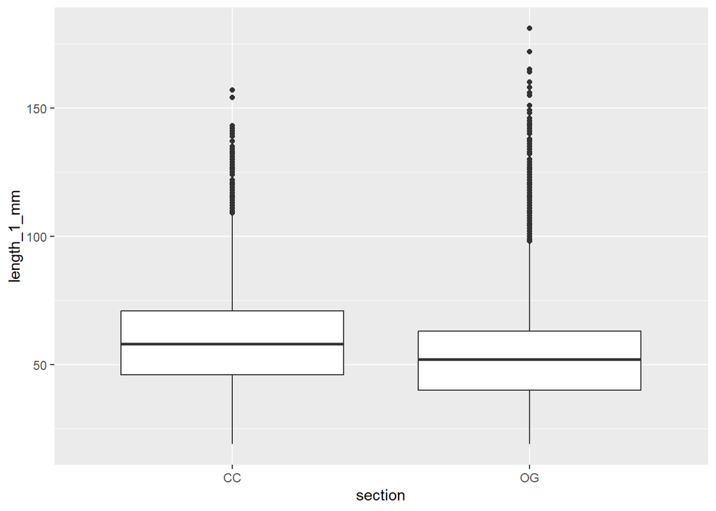

```r
cgs %>%
  ggplot(aes(x = section, y = length_1_mm))+
  geom_boxplot()
```

```r
# boxplots are a good way to show differences among groups
```

**2.** Conduct an ANOVA test to test for differences in snout-vent length between channel types (`unittype`, only using C, P and SC channel types) for the *Coastal Giant salamander*. Remember to check your test assumptions and use the appropriate test based on your findings. You must also conduct the associated post-hoc test and report which groups are significantly difference from each other (if any) (10 pts.)

### Conduct the ANOVA test:

```r
# use the same cgs data created in #1 but filter unit types
cgs_unit <- cgs %>%
  filter(unittype %in% c("C", "P", "SC"))
```

```r
# test for normality of our continuous variable in each group
cgs_unit %>%
  group_by(unittype) %>%
  shapiro_test(length_1_mm)

# as in #1, our group sample size is so large the shapiro test won't even run,
# so we can pass on this and focus on the equal variances assumption
```

```r
# test for equal variances among unittype
cgs_unit %>%
  levene_test(length_1_mm ~ unittype)
```

```
## # A tibble: 1 × 4
##     df1   df2 statistic        p
##   <int> <int>     <dbl>    <dbl>
## 1     2 11622      20.9 8.52e-10
```

```r
# our variances are NOT equal, so let's use the non parametric kruskal test
cgs_unit %>%
  kruskal_test(length_1_mm ~ unittype)
```

```
## # A tibble: 1 × 6
##   .y.             n statistic    df       p method
## * <chr>       <int>     <dbl> <int>   <dbl> <chr>
## 1 length_1_mm 11625      183.     2 2.3e-40 Kruskal-Wallis
```

```r
# out p-value is very small (~2.3e-40), so there is a significant difference in snout vent length
# between channel types. Now lets do the appropriate post-hoc test to view which groups are significantly different from each other
cgs_unit %>%
  dunn_test(length_1_mm ~ unittype)
```

```
## # A tibble: 3 × 9
##   .y.         group1 group2    n1    n2 statistic        p    p.adj p.adj.signif
## * <chr>       <chr>  <chr>  <int> <int>     <dbl>    <dbl>    <dbl> <chr>
## 1 length_1_mm C      P       7688  1943     -4.12 3.72e- 5 3.72e- 5 ****
## 2 length_1_mm C      SC      7688  1994    -13.4  3.70e-41 1.11e-40 ****
## 3 length_1_mm P      SC      1943  1994     -7.31 2.71e-13 5.43e-13 ****
```

```r
# We see a significant p-vlaue (looking at p.adj to adjust for multiple comparisons) among all group pairs
```

### Report the results:

There is a significant difference in Coastal giant salamander snout-vent length among cascade, pool and side channel types (p < 0.001).

### Visualize the results:

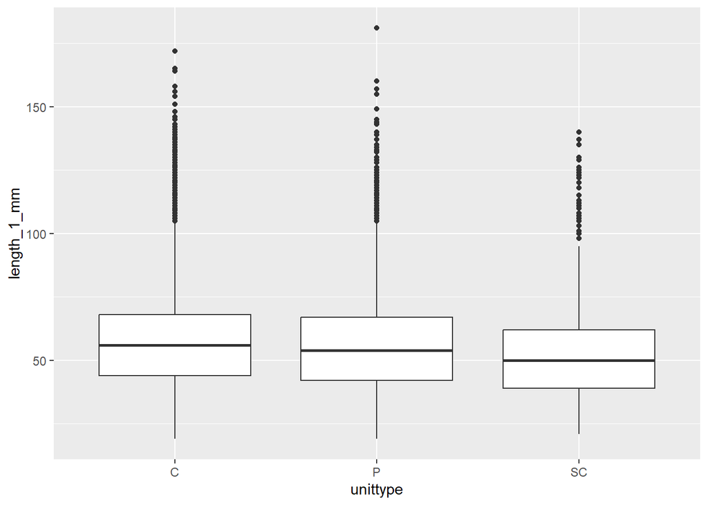

```r
cgs_unit %>%
  ggplot(aes(x = unittype, y = length_1_mm)) +
  geom_boxplot()
```